# A DFT study to develop a SiO<sub>2</sub> mesoporous surface model

Ciellie Jansen van Vuuren

6/12/2017

# Introduction

According to literature mesoporous support materials, are ideal heterogeneous support materials [2,3]. In this study, we decided to focus on the SBA-15 and MCM-41 mesoporous support material.

The first step in modelling a SBA-15 or MCM-41 mesoporous surface is to create an amorphous SiO2 bulk using an alpha-quartz (space group 180). The 3X3X3 supercell was submitted to dynamics studies using Materials Studio’s CASTEP module and VASP 5.3 [4,5]. This was done and I will discuss the procedure that I followed to accomplish this.

To do surface calculations it became very difficult, using the amorphous SiO2 bulk. We decide to use a crystalline 3X3X3 SiO2 bulk, using VASP 5.3. An Ab Initio Molecular Dynamics study will be done on all surfaces using VASP 5.3. A comparison between the amorphous and crystalline surfaces will be discussed

# Experimental work 2017

### 1. Amorphous SiO<sub>2</sub> Bulk

#### Method:

A 3x3x3 alpha-quartz, spacegroup 180, super-cell was built in the Materials Studio software package.

1. The annealing process of the alpha-quartz to obtain an amorphous solid was simulated using the CASTEP dynamic study module of the Materials Studio software package.
2. The bulk was heated to 4000, 5000 and 6000K in 50, 100 and 150 steps of 1fs each. After the heating step, the bulk was quenched to 1K in two 1fs steps.
3. Each resulting structure was again heated to 1000K in the same number of steps as in the first heating step and finally cooled down to 300K in the same number of steps.

- Energy
- Bond Angles
- Density of states
- Band Gap

#### Results

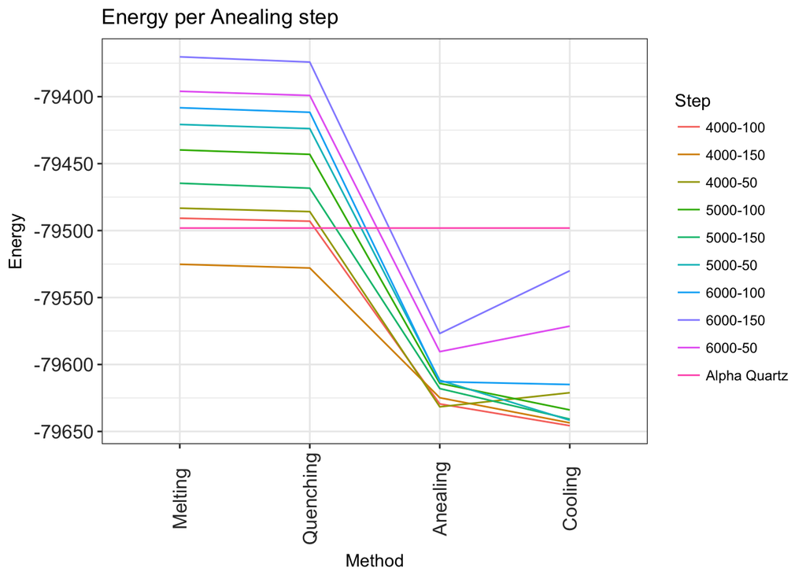

Table acording literature

[figure not shown]